# Iris Dataset Classification Model

## Exploratory Analysis

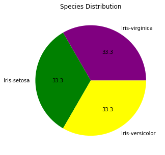

```python
plt.figure(figsize=(5,5))
data=list(df.species.value_counts())
colors=["purple","green","yellow"]
labels=["Iris-virginica",'Iris-setosa',"Iris-versicolor"]
plt.pie(data,labels=labels,colors=colors,autopct="%.1f")
plt.title("Species Distribution")
```

As we can see, the 3 species are evenly distributed throughout the dataset which is ideal because our classification model will then have an equal "understanding" of each species' features.

```python
vers=df[df.species.str.contains("versi")]
seto=df[df.species.str.contains("setos")]
virg=df[df.species.str.contains("virg")]
```

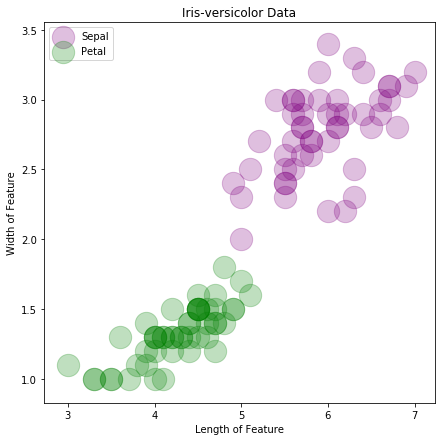

```python
versl=vers['sepal_length']
versw=vers['sepal_width']
verpl=vers['petal_length']
verpw=vers['petal_width']
plt.figure(figsize=(7,7))

plt.scatter(versl,versw,s=500,marker="o",c="purple",alpha=0.25)
plt.scatter(verpl,verpw,s=500,marker="o",c="green",alpha=0.25)
plt.title("Iris-versicolor Data")
plt.xlabel("Length of Feature")
plt.ylabel("Width of Feature")
plt.legend(("Sepal","Petal"),loc="upper left")
```

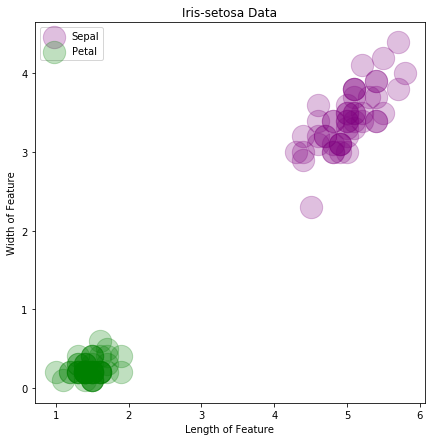

```python
versl=seto['sepal_length']
versw=seto['sepal_width']
verpl=seto['petal_length']
verpw=seto['petal_width']
plt.figure(figsize=(7,7))

plt.scatter(versl,versw,s=500,marker="o",c="purple",alpha=0.25)
plt.scatter(verpl,verpw,s=500,marker="o",c="green",alpha=0.25)
plt.title("Iris-setosa Data")
plt.xlabel("Length of Feature")
plt.ylabel("Width of Feature")
plt.legend(("Sepal","Petal"),loc="upper left")
```

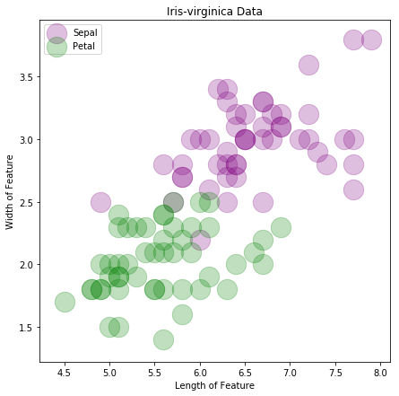

```python
versl=virg['sepal_length']
versw=virg['sepal_width']
verpl=virg['petal_length']
verpw=virg['petal_width']
plt.figure(figsize=(7,7))

plt.scatter(versl,versw,s=500,marker="o",c="purple",alpha=0.25)
plt.scatter(verpl,verpw,s=500,marker="o",c="green",alpha=0.25)
plt.title("Iris-virginica Data")
plt.xlabel("Length of Feature")
plt.ylabel("Width of Feature")
plt.legend(("Sepal","Petal"),loc="upper left")
```

We can infer from the data that the features of Iris-setosa dont really vary significantly, the features of Iris-virginica vary alot and the features of Iris-versicolor vary moderately.

## Decision Tree Classifier

### Splitting data into training and testing set

```python
df.head()
```

|  | sepal_length | sepal_width | petal_length | petal_width | species |
| --- | --- | --- | --- | --- | --- |
| 0 | 4.9 | 3.0 | 1.4 | 0.2 | Iris-setosa |
| 1 | 4.7 | 3.2 | 1.3 | 0.2 | Iris-setosa |
| 2 | 4.6 | 3.1 | 1.5 | 0.2 | Iris-setosa |
| 3 | 5.0 | 3.6 | 1.4 | 0.2 | Iris-setosa |
| 4 | 5.4 | 3.9 | 1.7 | 0.4 | Iris-setosa |

```python
sl=list(df.sepal_length)
sw=list(df.sepal_width)
pl=list(df.petal_length)
pw=list(df.petal_width)
sp=list(df.species)
```

```python
df
```

|  | sepal_length | sepal_width | petal_length | petal_width | species |
| --- | --- | --- | --- | --- | --- |
| 0 | 4.9 | 3.0 | 1.4 | 0.2 | Iris-setosa |
| 1 | 4.7 | 3.2 | 1.3 | 0.2 | Iris-setosa |
| 2 | 4.6 | 3.1 | 1.5 | 0.2 | Iris-setosa |
| 3 | 5.0 | 3.6 | 1.4 | 0.2 | Iris-setosa |
| 4 | 5.4 | 3.9 | 1.7 | 0.4 | Iris-setosa |
| 5 | 4.6 | 3.4 | 1.4 | 0.3 | Iris-setosa |
| 6 | 5.0 | 3.4 | 1.5 | 0.2 | Iris-setosa |
| 7 | 4.4 | 2.9 | 1.4 | 0.2 | Iris-setosa |
| 8 | 4.9 | 3.1 | 1.5 | 0.1 | Iris-setosa |
| 9 | 5.4 | 3.7 | 1.5 | 0.2 | Iris-setosa |
| 10 | 4.8 | 3.4 | 1.6 | 0.2 | Iris-setosa |
| 11 | 4.8 | 3.0 | 1.4 | 0.1 | Iris-setosa |
| 12 | 4.3 | 3.0 | 1.1 | 0.1 | Iris-setosa |
| 13 | 5.8 | 4.0 | 1.2 | 0.2 | Iris-setosa |
| 14 | 5.7 | 4.4 | 1.5 | 0.4 | Iris-setosa |
| 15 | 5.4 | 3.9 | 1.3 | 0.4 | Iris-setosa |
| 16 | 5.1 | 3.5 | 1.4 | 0.3 | Iris-setosa |
| 17 | 5.7 | 3.8 | 1.7 | 0.3 | Iris-setosa |
| 18 | 5.1 | 3.8 | 1.5 | 0.3 | Iris-setosa |
| 19 | 5.4 | 3.4 | 1.7 | 0.2 | Iris-setosa |
| 20 | 5.1 | 3.7 | 1.5 | 0.4 | Iris-setosa |
| 21 | 4.6 | 3.6 | 1.0 | 0.2 | Iris-setosa |
| 22 | 5.1 | 3.3 | 1.7 | 0.5 | Iris-setosa |
| 23 | 4.8 | 3.4 | 1.9 | 0.2 | Iris-setosa |
| 24 | 5.0 | 3.0 | 1.6 | 0.2 | Iris-setosa |
| 25 | 5.0 | 3.4 | 1.6 | 0.4 | Iris-setosa |
| 26 | 5.2 | 3.5 | 1.5 | 0.2 | Iris-setosa |
| 27 | 5.2 | 3.4 | 1.4 | 0.2 | Iris-setosa |
| 28 | 4.7 | 3.2 | 1.6 | 0.2 | Iris-setosa |
| 29 | 4.8 | 3.1 | 1.6 | 0.2 | Iris-setosa |
| ... | ... | ... | ... | ... | ... |
| 120 | 5.6 | 2.8 | 4.9 | 2.0 | Iris-virginica |
| 121 | 7.7 | 2.8 | 6.7 | 2.0 | Iris-virginica |
| 122 | 6.3 | 2.7 | 4.9 | 1.8 | Iris-virginica |
| 123 | 6.7 | 3.3 | 5.7 | 2.1 | Iris-virginica |
| 124 | 7.2 | 3.2 | 6.0 | 1.8 | Iris-virginica |
| 125 | 6.2 | 2.8 | 4.8 | 1.8 | Iris-virginica |
| 126 | 6.1 | 3.0 | 4.9 | 1.8 | Iris-virginica |
| 127 | 6.4 | 2.8 | 5.6 | 2.1 | Iris-virginica |
| 128 | 7.2 | 3.0 | 5.8 | 1.6 | Iris-virginica |
| 129 | 7.4 | 2.8 | 6.1 | 1.9 | Iris-virginica |
| 130 | 7.9 | 3.8 | 6.4 | 2.0 | Iris-virginica |
| 131 | 6.4 | 2.8 | 5.6 | 2.2 | Iris-virginica |
| 132 | 6.3 | 2.8 | 5.1 | 1.5 | Iris-virginica |
| 133 | 6.1 | 2.6 | 5.6 | 1.4 | Iris-virginica |
| 134 | 7.7 | 3.0 | 6.1 | 2.3 | Iris-virginica |
| 135 | 6.3 | 3.4 | 5.6 | 2.4 | Iris-virginica |
| 136 | 6.4 | 3.1 | 5.5 | 1.8 | Iris-virginica |
| 137 | 6.0 | 3.0 | 4.8 | 1.8 | Iris-virginica |
| 138 | 6.9 | 3.1 | 5.4 | 2.1 | Iris-virginica |
| 139 | 6.7 | 3.1 | 5.6 | 2.4 | Iris-virginica |
| 140 | 6.9 | 3.1 | 5.1 | 2.3 | Iris-virginica |
| 141 | 5.8 | 2.7 | 5.1 | 1.9 | Iris-virginica |
| 142 | 6.8 | 3.2 | 5.9 | 2.3 | Iris-virginica |
| 143 | 6.7 | 3.3 | 5.7 | 2.5 | Iris-virginica |
| 144 | 6.7 | 3.0 | 5.2 | 2.3 | Iris-virginica |
| 145 | 6.3 | 2.5 | 5.0 | 1.9 | Iris-virginica |
| 146 | 6.5 | 3.0 | 5.2 | 2.0 | Iris-virginica |
| 147 | 6.2 | 3.4 | 5.4 | 2.3 | Iris-virginica |
| 148 | 5.9 | 3.0 | 5.1 | 1.8 | Iris-virginica |
| 149 | 5.1 | 3.5 | 1.4 | 0.2 | Iris-setosa |

150 rows × 5 columns

```python
trainingX=[]
trainingY=[]
testingX=[]
testingY=[]
for i in range(112):#70:30 ratio
    trainingX.append([sl[i],sw[i],pl[i],pw[i]])
    trainingY.append(sp[i])
for i in range(112,150):#70:30 ratio
    testingX.append([sl[i],sw[i],pl[i],pw[i]])
    testingY.append(sp[i])
```

### Modelling the data

```python
from sklearn import tree
```

```python
classifier=tree.DecisionTreeClassifier()
```

```python
classifier.fit(trainingX,trainingY)
```

```
DecisionTreeClassifier(class_weight=None, criterion='gini', max_depth=None,
            max_features=None, max_leaf_nodes=None,
            min_impurity_decrease=0.0, min_impurity_split=None,
            min_samples_leaf=1, min_samples_split=2,
            min_weight_fraction_leaf=0.0, presort=False, random_state=None,
            splitter='best')
```

Now our Decision Tree Classifier can make predictions. We have to now measure the accuracy of our model.

```python
predicted=list(classifier.predict(testingX))
```

```python
counter=0
speciespred=[]
wrong=[]
for i in range(len(predicted)):
    if predicted[i]==testingY[i]:
        counter+=1
        speciespred.append(testingY[i])
    else:
        wrong.append(predicted)
print(counter)
```

```
27
```

```python
accuracy=(counter/len(predicted))*100
print(f"The accuracy of our model is {accuracy}%")
```

```
The accuracy of our model is 71.05263157894737%
```